# Introduction

This is the original dataset : “http://groupware.les.inf.puc-rio.br/static/WLE/WearableComputing_weight_lifting_exercises_biceps_curl_variations.csv.

The course instructors have provided different datasets : “https://d396qusza40orc.cloudfront.net/predmachlearn/pml-training.csv” and “https://d396qusza40orc.cloudfront.net/predmachlearn/pml-testing.csv”. For the sake of completeness, we examine differences between both original and instructors’ datasets.

The original dataset is used in this article : “http://groupware.les.inf.puc-rio.br/public/papers/2013.Velloso.QAR-WLE.pdf”.

To summarize the article (and understand the dataset), 6 participants were asked to perform 5 ways of doing a dumbbell bicep curl, with 10 repetitions per way. Out of the 5 ways, method A is correct while method B to E represent common mistakes.

The movements are recorded over 4 sensors mounted at the participants’ belts, arms, dumbbells and forearms. Each of these sensors records 3 axes of 4 measurement types : Euler angles (roll, pitch and yaw), accelerometer, gyroscope (orientation to earth’s gravitational centre) and magnetometer (orientation to earth’s magnetic north).

So per row (per unit time), we should see 48 columns (4 sensor positions x 3 axes x 4 measurement types) of raw data. The rows are sliced into 1-second intervals for calculating 8 statistical features : mean, variance, standard deviation, maximum, minimum, range, kurtosis and skew. These statistical features are only present in rows representing end of each 1-second interval.

# Downloading & Inspecting & Cleaning The Datasets

```r
training.URL <- "https://d396qusza40orc.cloudfront.net/predmachlearn/pml-training.csv"
testing.URL <- "https://d396qusza40orc.cloudfront.net/predmachlearn/pml-testing.csv"
original.URL <- "http://groupware.les.inf.puc-rio.br/static/WLE/WearableComputing_weight_lifting_exercises_biceps_curl_variations.csv"

# download.file(training.URL, "C:/Users/angdy/Desktop/training.csv")
# download.file(testing.URL, "C:/Users/angdy/Desktop/testing.csv")
# download.file(original.URL, "C:/Users/angdy/Desktop/original.csv")

training <- read.csv("C:/Users/angdy/Desktop/training.csv", na.strings=c("#DIV/0!","NA",""))
testing <- read.csv("C:/Users/angdy/Desktop/testing.csv", na.strings=c("#DIV/0!","NA",""))
original <- read.csv("C:/Users/angdy/Desktop/original.csv", na.strings=c("#DIV/0!","NA",""))

# str(training); head(training); tail(training)
# str(testing); head(testing); tail(testing)
# str(original); head(original); tail(original)
```

We make 5 observations about the datasets :

1. The instructors’ dataset appears to have taken only half of the original dataset.
2. The columns for statistical features are only filled for end of each 1-second interval.
3. The statistical features have many calculation and label errors e.g. values for **kurtosis_pitch_belt** are actually for **kurtosis_roll_belt** and **skewness_roll_belt.1** should be labelled **skewness_pitch_belt**.
4. The instructors did not recalculate statistical features upon removing half the data, thus statistical features no longer reflect structure of remaining data.
5. Each value in **raw_timestamp_part_1** represents a 1-second interval while **raw_timestamp_part_2** represents time splits within one interval.

As such, we make 3 recommendations about cleaning the datasets :

1. To remove all columns for statistical features (and maybe re-calculate).
2. To remove other columns with no information value, namely **cvtd_timestamp**, **new_window** and **num_window**.
3. To sort rows by **user_name**, **raw_timestamp_part_1** and **raw_timestamp_part_2** in that order for clarity.

```r
training$X <- NULL
testing$X <- NULL
removal.terms <- c("kurtosis","skewness","max_","min_","amplitude",
                   "var_","avg_","stddev","cvtd_","new_window","num_window")
removal.list <- unique(unlist(sapply(removal.terms,grep,names(training))))
training <- training[,-removal.list]
testing <- testing[,-removal.list]
original <- original[,-removal.list]

training <- training[with(training,order(user_name,
                                   raw_timestamp_part_1,
                                   raw_timestamp_part_2)),]
original <- original[with(original,order(user_name,
                                         raw_timestamp_part_1,
                                         raw_timestamp_part_2)),]
```

After sorting rows according to user and time, it is clear that each user was asked to perform repetitions of “classe” type A to E in an alphabetical order. Charts in our exploratory data analysis should reflect that.

# Exploratory Data Analysis

We will only sample 4 charts from instructors’ dataset and another similar 4 charts from original dataset. This will allow us to see how the raw data looks like as a time series chart and also let us compare both datasets against each other.

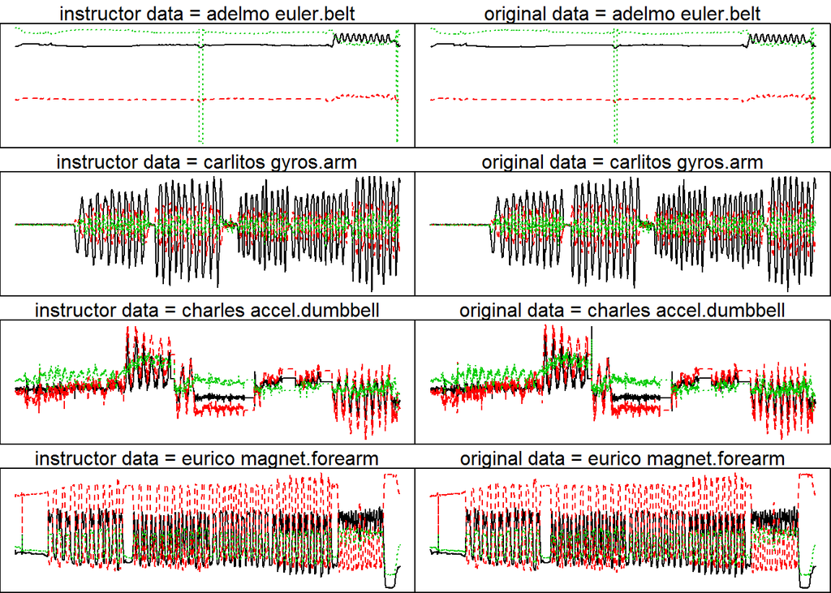

```r
par(mfrow=c(4,2), mar=c(0,0,1.5,0), oma=c(0,0,0,0))

users <- c("adelmo","carlitos","charles","eurico","jeremy","pedro")
euler.belt <- c("roll_belt","pitch_belt","yaw_belt")
gyros.arm <- c("gyros_arm_x","gyros_arm_y","gyros_arm_z")
accel.dumbbell <- c("accel_dumbbell_x","accel_dumbbell_y","accel_dumbbell_z")
magnet.forearm <- c("magnet_forearm_x","magnet_forearm_y","magnet_forearm_z")
sample.features <- list(euler.belt=euler.belt,
                        gyros.arm=gyros.arm,
                        accel.dumbbell=accel.dumbbell,
                        magnet.forearm=magnet.forearm)

for (i in 1:4) {
    ss <- sample.features[i]
    tt <- training[training$user_name==users[i], unlist(ss)]
    oo <- original[original$user_name==users[i], unlist(ss)]
    matplot(tt, type="l", xaxt="n", yaxt="n")
    mtext(paste("instructor data =", users[i], ylab=names(ss)), side=3)
    matplot(oo, type="l", xaxt="n", yaxt="n")
    mtext(paste("original data =", users[i], ylab=names(ss)), side=3)
}
```

We make 3 observations about the datasets :

1. Both datasets produce charts looking similar, despite instructors having removed half the data. They likely used an algorithm to reduce rows while retaining similar variation.
2. For most of the charts, we can see 5 different cross-sections that likely pertain to 5 different ways of doing bicep curls over time.
3. Each cross-section contains 10 pairs of up-and-down spikes which likely represent repetitions of bicep curls.

As we surveyed the online landscape on this research topic, we also chanced upon another article that expands research on the same dataset : “https://socialnui.unimelb.edu.au/publications/2016-SocialNUI-Kowsar.pdf”.

The interesting observation from this other article’s exploratory data analysis is that 2 of the participants did not do “classe A” of bicep curl correctly i.e. they moved their hips during the exercise and this can be seen from charted data.

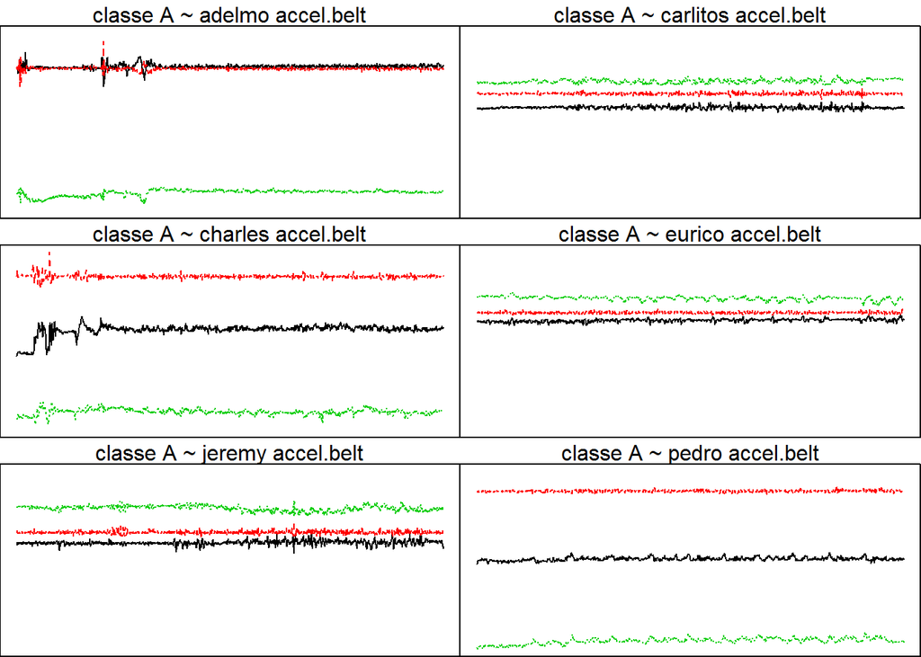

```r
par(mfrow=c(3,2), mar=c(0,0,1.5,0), oma=c(0,0,0,0))

users <- c("adelmo","carlitos","charles","eurico","jeremy","pedro")
accel.belt <- c("accel_belt_x","accel_belt_y","accel_belt_z")

oo <- original[original$classe=="A", accel.belt]
maxi <- max(oo)
mini <- min(oo)

for (i in 1:6) {
    oo <- original[original$user_name==users[i] & original$classe=="A",
                   accel.belt]
    matplot(oo, type="l", xaxt="n", yaxt="n", ylim=c(mini,maxi))
    mtext(paste("classe A ~", users[i], "accel.belt"), side=3)
}
```

# Pre-Processing Of Predictors

There are 3 things to consider under this section, namely do we

1. (re-calculate) and include statistical features or just stick with raw data ?
2. reduce white noise with techniques such as Kalman filter ?
3. reduce dimensionality (removing irrelevant or redundant features) with techniques such as principal component analysis (PCA) ?

Regarding (1), the test data set has null values for all statistical features so including any statistical features in our training data set would be pointless. However it is worth noting that in the original article, the authors used a correlation-based feature selection (CFS) algorithm (“https://www.cs.waikato.ac.nz/~mhall/thesis.pdf”) and found 17 statistical features to be more relevant.

Regarding (2), article “https://socialnui.unimelb.edu.au/publications/2016-SocialNUI-Kowsar.pdf” states that any motion sensor will come with white noise and any successful analysis of the data must first remove this white noise. The authors chose to use a density-based Kalman filter, however this is beyond the syllabus of this project.

Regarding (3), we are left with 52 variables and suspect that some could be redundant e.g. changes in **gyros_forearm_x** may be making similar measurements to changes in **magnet_forearm_x** i.e. changes in absolute positioning relative to Earth’s gravitational centre and magnetic north respectively. While many models (such as classification trees and random forests) have built-in feature selection, it could be meaningful to attempt dimensionality reduction with PCA.

# Model Selection & Parameters Tuning & Cross-Validation Methods

For the purpose of exploration (and learning more), we will try a variety of pre-processing options, models, tuning customizations and cross-validation methods. To speed things up, we will utilize parallel processing for suitable models. To get honest estimates of accuracy, all data transformations will be included within the cross-validation loop. This is especially true for feature selection and pre-processing e.g. imputation and PCA.

# How We Build Each Model , How We Used Cross Validation

For quadratic discriminant analysis, we will run it against both raw data and principal components. This model is computationally less intensive and is therefore suitable for a computationally more intensive method of cross-validation such as “leave one out” i.e. we divide the data set into two parts. In one part we have a single observation, which is our test data and in the other part, we have all the other observations from the dataset forming our training data. This process is iterated for every data point and generates n times accuracy numbers which we will average.

Classification trees does tuning over a cost-complexity measure. We set tuning length to 5 (instead of default 3), to try a greater variety of values for this measure. We will use “repeated k-fold” cross-validation as this model is also computationally less intensive. Statistically speaking, a problem in using k-fold is that the k repetitions are not independent of one another, meaning that your estimator is biased. Making repeated k-fold may lower this bias.

Bagging (or bootstrap aggregating) will be run and cross-validated over the default of 25 bootstrap samples. Each sample will be taken with replacement from the training data set. This attempts to simulate variability in the data but it also underestimates the error.

For random forests, the default is that 500 bootstrapped trees will be grown and tuned over 3 values of “mtry” (which refers to number of variables sampled at each node). To reduce computation time, we reduce the number of trees to 250 but increased tuning length to 5 instead. The “out-of-bag” method will also be used to estimate error rate. This method compares prediction values for each tree grown to values unused in that tree’s bootstrap to get an error rate for aggregation across all trees.

Boosting is very computationally intensive and we will just use 5-fold cross-validation for it. To increase its accuracy, we will increase tuning length to 5 i.e. overall, 5 interaction depths for 5 differing numbers of trees on 5 repeated folds.

For support vector machines, there are various versions i.e. linear, polynomial and radial. We will choose the radial version and use “leave group out” cross-validation with number=5 and p=0.65. What this means is that a partial sample will be taken without replacement from the training dataset, leaving 35% of data behind. Predictive values from the partial sample will be validated against the 35% remaining and this whole process will be repeated 5 times.

```r
training[,c("user_name","raw_timestamp_part_1","raw_timestamp_part_2")] <- NULL
testing[,c("user_name","raw_timestamp_part_1","raw_timestamp_part_2")] <- NULL
original[,c("user_name","raw_timestamp_part_1","raw_timestamp_part_2")] <- NULL

library(caret)
library(parallel)
library(doParallel)
start.time <- Sys.time()

# model-based quadratic discriminant analysis
trControl <- trainControl(method="LOOCV")
train(classe~., data=training, method="qda", trControl=trControl)
```

```
## Quadratic Discriminant Analysis
##
## 19622 samples
##    52 predictor
##     5 classes: 'A', 'B', 'C', 'D', 'E'
##
## No pre-processing
## Resampling: Leave-One-Out Cross-Validation
## Summary of sample sizes: 19621, 19621, 19621, 19621, 19621, 19621, ...
## Resampling results:
##
##   Accuracy   Kappa
##   0.8930282  0.8649205
```

```r
train(classe~., data=training, method="qda", trControl=trControl,
      preProcess="pca")
```

```
## Quadratic Discriminant Analysis
##
## 19622 samples
##    52 predictor
##     5 classes: 'A', 'B', 'C', 'D', 'E'
##
## Pre-processing: principal component signal extraction (52), centered
##  (52), scaled (52)
## Resampling: Leave-One-Out Cross-Validation
## Summary of sample sizes: 19621, 19621, 19621, 19621, 19621, 19621, ...
## Resampling results:
##
##   Accuracy   Kappa
##   0.7384059  0.6724867
```

```r
# trees, parameters = splits, depth, cost-complexity
trControl <- trainControl(method="repeatedcv", number=5, repeats=5)
train(classe~., data=training, method="rpart", tuneLength=5,
      trControl=trControl)
```

```
## CART
##
## 19622 samples
##    52 predictor
##     5 classes: 'A', 'B', 'C', 'D', 'E'
##
## No pre-processing
## Resampling: Cross-Validated (5 fold, repeated 5 times)
## Summary of sample sizes: 15699, 15697, 15695, 15699, 15698, 15698, ...
## Resampling results across tuning parameters:
##
##   cp          Accuracy   Kappa
##   0.02193420  0.5685455  0.44328693
##   0.02983905  0.5283456  0.38487141
##   0.03567868  0.5058913  0.35470781
##   0.05998671  0.4314024  0.23425015
##   0.11515454  0.3294970  0.06881418
##
## Accuracy was used to select the optimal model using the largest value.
## The final value used for the model was cp = 0.0219342.
```

```r
cluster <- makeCluster(detectCores()-1)
registerDoParallel(cluster)

  # bagging, parameters = no. of bootstraps
  train(classe~., data=training, method="treebag")
```

```
## Bagged CART
##
## 19622 samples
##    52 predictor
##     5 classes: 'A', 'B', 'C', 'D', 'E'
##
## No pre-processing
## Resampling: Bootstrapped (25 reps)
## Summary of sample sizes: 19622, 19622, 19622, 19622, 19622, 19622, ...
## Resampling results:
##
##   Accuracy   Kappa
##   0.9826391  0.9780333
```

```r
  ## random forests, parameters = "nodesize", "maxnodes", "mtry", "max_depth"
  trControl <- trainControl(method="oob")
  set.seed(123)
  mf.rf <- train(classe~., data=training, method="rf", tuneLength=5,
                 trControl=trControl, ntree=250); mf.rf
```

```
## Random Forest
##
## 19622 samples
##    52 predictor
##     5 classes: 'A', 'B', 'C', 'D', 'E'
##
## No pre-processing
## Resampling results across tuning parameters:
##
##   mtry  Accuracy   Kappa
##    2    0.9950056  0.9936822
##   14    0.9965345  0.9956164
##   27    0.9956172  0.9944559
##   39    0.9942412  0.9927152
##   52    0.9900622  0.9874283
##
## Accuracy was used to select the optimal model using the largest value.
## The final value used for the model was mtry = 14.
```

```r
  ## boosting, parameters = no. of iterative steps, "interaction.depth", "n.trees"
  trControl <- trainControl(method="cv", number=5)
  set.seed(123)
  mf.boost <- train(classe~., data=training, method="gbm", tuneLength=5,
                    trControl=trControl, verbose=FALSE); mf.boost
```

```
## Stochastic Gradient Boosting
##
## 19622 samples
##    52 predictor
##     5 classes: 'A', 'B', 'C', 'D', 'E'
##
## No pre-processing
## Resampling: Cross-Validated (5 fold)
## Summary of sample sizes: 15697, 15698, 15696, 15699, 15698
## Resampling results across tuning parameters:
##
##   interaction.depth  n.trees  Accuracy   Kappa
##   1                   50      0.7540514  0.6882622
##   1                  100      0.8230555  0.7760418
##   1                  150      0.8542964  0.8156057
##   1                  200      0.8751912  0.8420069
##   1                  250      0.8899703  0.8606969
##   2                   50      0.8571501  0.8190055
##   2                  100      0.9087248  0.8844963
##   2                  150      0.9340535  0.9165469
##   2                  200      0.9505653  0.9374561
##   2                  250      0.9604521  0.9499698
##   3                   50      0.8954744  0.8676891
##   3                  100      0.9412897  0.9257111
##   3                  150      0.9624906  0.9525429
##   3                  200      0.9717660  0.9642814
##   3                  250      0.9786463  0.9729872
##   4                   50      0.9247266  0.9047373
##   4                  100      0.9611148  0.9508082
##   4                  150      0.9743145  0.9675067
##   4                  200      0.9825705  0.9779515
##   4                  250      0.9864947  0.9829164
##   5                   50      0.9390476  0.9228451
##   5                  100      0.9696769  0.9616380
##   5                  150      0.9820102  0.9772405
##   5                  200      0.9870044  0.9835595
##   5                  250      0.9904698  0.9879441
##
## Tuning parameter 'shrinkage' was held constant at a value of 0.1
##
## Tuning parameter 'n.minobsinnode' was held constant at a value of 10
## Accuracy was used to select the optimal model using the largest value.
## The final values used for the model were n.trees = 250,
##  interaction.depth = 5, shrinkage = 0.1 and n.minobsinnode = 10.
```

```r
  ## svm, parameters = cost, polynomial degree, radial basis
  trControl <- trainControl(method="LGOCV", number=5, p=0.65)
  set.seed(123)
  mf.svm <- train(classe~., data=training, method="svmRadial", tuneLength=9,
                  trControl=trControl); mf.svm
```

```
## Support Vector Machines with Radial Basis Function Kernel
##
## 19622 samples
##    52 predictor
##     5 classes: 'A', 'B', 'C', 'D', 'E'
##
## No pre-processing
## Resampling: Repeated Train/Test Splits Estimated (5 reps, 65%)
## Summary of sample sizes: 12757, 12757, 12757, 12757, 12757
## Resampling results across tuning parameters:
##
##   C      Accuracy   Kappa
##    0.25  0.8662491  0.8304375
##    0.50  0.8974800  0.8700105
##    1.00  0.9247196  0.9045861
##    2.00  0.9495703  0.9361106
##    4.00  0.9659723  0.9569113
##    8.00  0.9762272  0.9699112
##   16.00  0.9825492  0.9779191
##   32.00  0.9881719  0.9850368
##   64.00  0.9914931  0.9892390
##
## Tuning parameter 'sigma' was held constant at a value of 0.01376431
## Accuracy was used to select the optimal model using the largest value.
## The final values used for the model were sigma = 0.01376431 and C = 64.
```

```r
stopCluster(cluster)
registerDoSEQ()

end.time <- Sys.time()
end.time - start.time
```

```
## Time difference of 3.583088 hours
```

# What We Think Expected Out-Of-Sample Error Rates Are

Based on cross-validated accuracies, random forests, boosting and support vector machines have the best results. We expect out-of-sample accuracies to be 0.9965, 0.9905 and 0.9915 respectively for the above top 3 models.

Dimensionality reduction using PCA is not fruitful as it reduces accuracies across all models in our initial trials (not documented here except for quadratic discriminant analysis).

# Making Predictions

```r
predict(mf.rf, testing)
```

```
##  [1] B A B A A E D B A A B C B A E E A B B B
## Levels: A B C D E
```

```r
predict(mf.boost, testing)
```

```
##  [1] B A B A A E D B A A B C B A E E A B B B
## Levels: A B C D E
```

```r
predict(mf.svm, testing)
```

```
##  [1] B A B A A E D B A A B C B A E E A B B B
## Levels: A B C D E
```

It is interesting to note that the 20 predictions on test dataset from all 3 models are identical. In that case, ensembling (stacking the 3 models) would not make any difference here.